# Kwestionariusz Defensywnego Pesymizmu - przeprowadzone badania

Michał Kosiński

10 05 2021

## Wstęp

W przebiegu badań do swojej pracy magisterskiej, przeprowadzałem badanie z wykorzystaniem opublikowanej przez Panią adaptacji Kwestionariusza Defensywnego Pesymizmu. W Pani publikacji (Szpitalak 2016) widnieje informacja dotycząca trójczynnikowej struktury kwestionariusza po adaptacji. W związku z tym podjąłem decyzję o próbie dodania dodatkowych pozycji, które miałyby za zadanie uchwycić badany konstrukt.

## Aspekt myśli prefaktycznych

Podczas konstrukcji dodatkowych pozycji, kierowałem się, obok samej teorii Defensywnego Pesymizmu (Norem 2001) również tworzonymi przez *defensywnych pesymistów* symulacjami wyobrażeniowymi - dokładniej *myślami prefaktycznymi zwyżkowymi* (Epstude, Scholl, and Roese 2016), czyli charakterystycznym przewidywaniem negatywnego wydarzenia.

Słowo wyjaśnienia dotyczącego *myśli prefaktycznych* z opracowań Epstude i Roese’a (2016) - są to symulacje wyobrażeniowe konstruowane przed nadchodzącym zadaniem, wydarzeniem. Poprzedza je pierwotne oczekiwanie dotyczące przebiegu wydarzenia, dotyczą one bowiem *alternatywnego* dla niego przebiegu, w przypadku zmiany któregoś z elementu oczekiwanego scenariusza. Kierunek symulacji wyobrażeniowych może być natomiast *zwyżkowy* lub *zniżkowy* - w zależności od tego, czy alternatywny, wyobrażeniowy tok wydarzeń jest subiektywnie odbierany jako *lepszy* bądź *gorszy*.

W przebiegu wielu badań eksperymentalnych to właśnie ilość generowanych *myśli prefaktycznych zwyżkowych* była głownym wyróżnikiem defensywnych pesymistów w porównaniu do strategicznych optymistów jak i pesymistów realistycznych Valle and Mateos (2008). Co więcej, obecna w tych badaniach indukcja nastroju do złudzenia przypomina manipulację zastosowaną przez Spencer i Norem w swoim eksperymencie (1996), przekładając się na analogiczne wyniki: *defensywni pesymiści* podczas indukcji negatywnego afektu lub w warunkach odsłuchania *coping tape* (prowadzącego do wyobrażenia sobie porażki) radzili sobie w zadaniu **lepiej** niż *strategiczni optymiści*. Odwrotne różnice występowały natomiast w przypadku indukcji afektu pozytywnego lub po odsłuchaniu *taśmy relaksacyjnej* (obniżającej napięcie). Prowadzi to do wniosku że obydwa konstrukty - tendencja do stosowania strategii poznawczej na wymiarze *defensywny pesymizm - strategiczny optymizm* jak i *myśli prefaktyczne* są mocno ze sobą związane.

### Dodatkowe itemy

Stworzone itemy w założeniu miały ładować czynnik *Refleksyjności* (jako, że w Pani badaniach to on głównie uległ rozszczepieniu na dwa odrębne czynniki) oraz tworzyć dodatkowy czynnik wraz z itemem 3., który w anglojęzycznej skali służył do wyodrębnienia pesymistów realistycznych od defensywnych (roboczo nazwany: *Realizm*).

Dodatkowe pozycje włączone w skład kwestionariusza

| Lp | Treść itemu | Przewidywana skala |
| --- | --- | --- |
| 18 | Gdy wiem, że czeka mnie taka sytuacja, poświęcam dużo czasu na przygotowanie do niej, aby wypaść jak najlepiej. | Refleksyjność |
| 19 | Zazwyczaj zastanawiam się, co może pójść nie tak w sytuacjach tego typu. | Refleksyjność |
| 20 | Mimo, że bardzo stresują mnie takie sytuacje, zazwyczaj w przeszłości udawało mi się z nich wyjść obronną ręką. | Realizm |
| 21 | Przed takimi sytuacjami zastanawiam się raczej nad tym, co pójdzie po mojej myśli. | Refleksyjność |
| 22 | Zazwyczaj przed takimi sytuacjami nie myślę o błędach, które mogę popełnić. | Refleksyjność (-) |
| 23 | Raczej przed takimi sytuacjami staram się nie brać pod uwagę możliwości porażki. | Refleksyjność (-) |
| 24 | Przewidywanie najgorszych scenariuszy pomaga mi lepiej przygotować się do takich sytuacji. | Refleksyjność |
| 25 | Mimo wcześniejszych sukcesów odnoszonych w takich sytuacjach, zazwyczaj czuję przed nimi lęk. | Realizm |

### Wyniki analizy czynnikowej

W przeprowadzanym badaniu wzięło udział 247 osób (180 kobiet, 60 mężczyzn, 7 b/d) w wieku od 15 do 62 lat (M = 24.2). Analiza eksploracyjna, podobnie jak w Pani badaniach wskazała zasadność wyłonienia 3 czynników, choć struktura była tutaj nieco inna. Przeprowadziłem konfirmacyjną analizę dla trzech różnych modeli: 2-czynnikowego i 3-czynnikowego według Pani opracowania oraz 3-czynnikowy, z rozszerzoną strukturą (estymator: DWLS). Porównując wartości wskaźników dopasowania, 3-czynnikowy model rozszerzony wykazał najlepsze dopasowanie (choć nadal nie do końca zadowalające, szczególnie ze względu na wartość RMSEA).

Dobroci dopasowania modeli kwestionariusza w moim badaniu

| Model | CFI | TLI | RMSEA | 95% CI lower | 95% CI upper |
| --- | --- | --- | --- | --- | --- |
| 2 czynnikowy | 0.849 | 0.812 | 0.129 | 0.114 | 0.144 |
| 3 czynnikowy | 0.903 | 0.875 | 0.105 | 0.089 | 0.121 |
| 3 czynnikowy (rozszerzony) | 0.937 | 0.923 | 0.083 | 0.07 | 0.097 |

Większość pozycji zawartej w pierwotnej polskiej adaptacji pozostały w strukturze kwestionariusza - jedynym wyjątkiem był item 16., który już podczas analizy eksploracyjnej nie został włączony w strukturę. Do czynnika *Oczekiwania sukcesu* w jego miejsce został włączony nowy item. Czynniki *Oczekiwania porażki* oraz *Refleksyjności* zostały rozszerzone o jedną pozycję testową.

[output not shown]

Wartości pogrubione przedstawiają ładunki czynnikowe wersji rozszerzonej; POR - Oczekiwanie porażki, REFL - Refleksyjność, SUK - Oczekiwanie sukcesu

### Analiza rzetelności wersji rozszerzonej

Przeprowadzona analiza zgodności wewnętrznej wskazała na zadowalające wartości $\alpha$ Cronbacha dla wszystkich podskal oraz Wyniku ogólnego kwestionariusza (który został wyliczony jako suma podskal *Oczekiwania porażki* i *Refleksyjności* oraz odwróconej podskali *Oczekiwania sukcesu*).

Wskaźniki zgodności wewnętrznej wersji rozszerzonej

| Podskala | k | α | α std. | CI 95% lower | CI 95% upper |
| --- | --- | --- | --- | --- | --- |
| Oczekiwanie porażki | 7 | 0.88 | 0.88 | 0.86 | 0.90 |
| Oczekiwanie sukcesu | 3 | 0.78 | 0.78 | 0.72 | 0.82 |
| Refleksyjność | 4 | 0.77 | 0.77 | 0.72 | 0.81 |
| Wynik ogólny | 14 | 0.82 | 0.82 | 0.78 | 0.85 |

### Analiza trafności wersji rozszerzonej

#### Trafność w porównaniach międzygrupowych

Pierwotnym moim zamiarem było ustalenie punktów odcięcia, podobnych do stosowanych przez Julie Norem (2001) służących do klasyfikacji badanych ze względu na przeważającą strategię poznawczą (uwzględnienie itemu 3. w podziale na pesymistów defensywnych i realistycznych). Jednakże, ze względu na wyłonienie skali *Oczekiwanie sukcesu* oraz niepewność jej roli w obliczaniu *Wyniku ogólnego* kwestionariusza, przeprowadziłem serię analiz usiłujących wydzielić odpowiednie punkty odcięcia na podstawie wyników różnych podskal. Kryterium miała być Skala Poczucia Beznadziei (Oleś and Juros 1986) - anglojęzyczne narzędzie było wykorzystane jako kryterium było w analizach trafności pierwszego narzędzia autorstwa Norem i Cantor (1986).

W dotychczasowych próbach nie udało się jednak wyłonić wystarczająco silnego kryterium służącego do różnicowania defensywnych i realistycznych pesymistów. Może być to związane z faktem, że autorki OPPQ do wyłonienia pesymistów realistycznych spośród osób astrategicznych wykorzystały *Life Orientation Test* Carvera, do którego ja nie miałem dostępu - moje próby były związane jedynie z danymi uzyskanymi poprzez badanie *KDP*.

Najsilniejsze rozróżnienie udało się uzyskać, przyjmując jako kryteria podziału:

- Defensywni pesymiści: osoby uzyskujące *Wynik ogólny* powyżej 76 centyla i item 3. większy bądź równy 5;
- Strategiczni optymiścy: osoby uzyskujące wynik podskal *Oczekiwanie porażki* niższy bądź równy 40 centyla i *Oczekiwanie sukcesu* powyżej 60 centyla;
- Realistyczni (dyspozycyjni) pesymiści: osoby uzyskujące wynik podskal *Oczekiwanie porażki* powyżej mediany i *item 3.* poniżej 5;
- Osoby astrategiczne: pozostali badani.

| Grupa 1 | Grupa 2 | n1 | n2 | z | p | p.popr |  |
| --- | --- | --- | --- | --- | --- | --- | --- |
| Astrategiczni | Defensywni pesymiści | 38 | 15 | 1.27 | 0.204 | 0.245 |  |
| Astrategiczni | Dyspozycyjni pesymiści | 38 | 14 | 2.08 | 0.038 | 0.057 |  |
| Astrategiczni | Strategiczni optymiści | 38 | 15 | -2.56 | 0.010 | 0.021 | * |
| Defensywni pesymiści | Dyspozycjni pesymiści | 15 | 14 | 0.70 | 0.482 | 0.482 |  |
| Defensywni pesymiści | Strategiczni optymiści | 15 | 15 | -3.20 | 0.001 | 0.004 | ** |
| Dyspozycyjni pesymiści | Strategiczni optymiści | 14 | 15 | -3.85 | 0.000 | 0.001 | *** |

Oprócz *Skali Poczucia Beznadziei* (Oleś and Juros 1986) przeprowadziłem również badanie różnic międzygrupowych z wykorzystaniem adaptowanego przeze mnie na potrzeby pracy magisterskiej narzędzia: Skali Myśli Kontrfaktycznych w *Następstwie Negatywnego Wydarzenia* (ang. Counterfactual Thinking for Negative Events Scale, Rye et al. 2008). Skala ta zawiera cztery podskale różnych rodzajów *myśli kontrfaktycznych*: myśli zniżkowe bez zogniskowania, myśli zwyżkowe bez zogniskowania, zogniskowane na sobie i zogniskowane na innych.

| Grupa 1 | Grupa 2 | n1 | n2 | z | p | p.popr |  |
| --- | --- | --- | --- | --- | --- | --- | --- |
| Astrategiczni | Defensywni pesymiści | 88 | 19 | -2.45 | 0.014 | 0.035 | * |
| Astrategiczni | Strategiczni optymiści | 88 | 23 | 0.36 | 0.719 | 0.719 |  |
| Defensywni pesymiści | Strategiczni optymiści | 19 | 23 | 2.27 | 0.023 | 0.035 | * |

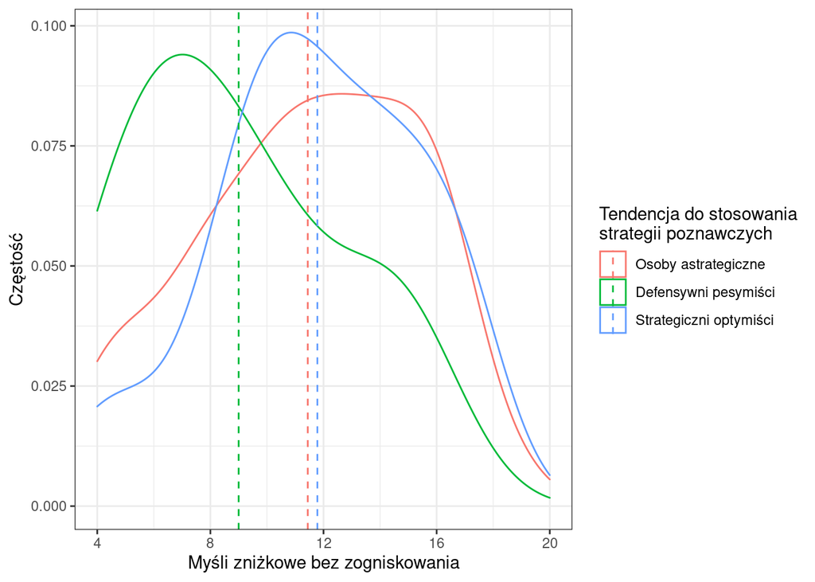

Jest to spójne z wynikami del Valle i Mateos: *myśli zniżkowe bez zogniskowania* są stosowane głównie jako metoda ochrony ego, co jest związane głównie ze stylem optymistycznym.

Zważając na niskie liczebności grup (ogólna liczebność próby badanych wypełniających jednocześnie *KDP* i *Skalę beznadziejności* wyniosła 82 osoby, a *KDP* i *Skalę myśli kontrfaktyczych*), może być to prawidłowy kierunek poszukiwań, choć należy poświęcić jeszcze czas na ustalenie odpowiednich kryteriów klasyfikacji do grup. Możliwe, że będzie to niemożliwe bez przeprowadzenie badań eksperymentalnych (z wolnym wytwarzaniem *symulacji wyobrażeniowych* przez osoby badane).

### Trafność korelacyjna

Zważając na niepewne kryteria klasyfikacyjne w powyższych analizach, przeprowadziłem dodatkowo analizę korelacyjną podskal *KDP* z podskalami *Skali myśli kontrfaktycznych* (jednostronny test korelacji rang Spearmana w kierunku związków dodatnich). Wyniki testu wskazały na: - istotne statystycznie związki wszystkich rodzajów *myśli zwyżkowych* z podskalą *oczekiwania porażki* - istotne statystycznie związek *myśli zniżkowych bez zogniskowania* oraz *myśli zwyżkowych zogniskowanych na innych* z podskalą *oczekiwania sukcesu*. Również są to związki oczekiwane, ponieważ oczekiwanie sukcesu można powiązać z podejściem optymistycznym, a myśli zniżkowe są powiązane z ochroną ego. Podobną funkcję mogą pełnić myśli zwyżkowe zogniskowane na innych - umiejscawiając “winę” za negatywny przebieg wydarzenia w innych ("gdyby ktoś inny zachował się inaczej, nie byłoby tak źle) uciekamy od odpowiedzialności. - istotnie statystycznie związki *myśli zwyżkowych zogniskowanych na innych* oraz *bez zogniskowania* z podskalą *refleksyjności* - nie umiejscawiamy wówczas siebie jako głównej przyczyny negatywnego zdarzenia, jednak poszukujemy w dalszym stopniu rozwiązań, które mogą być przydatne w przyszłości. Wskazuje to również na wagę *Oczekiwania porażki* w strategii Defensywnego pesymizmu - pozwala to na wyciąganie najbardziej adaptacyjnych wniosków z wydarzeń poprzednich: największy wpływ mamy bowiem na swoje własne zachowania, możemy je modyfikować podczas przyszłych, podobnych zadań.

Wyniki test Spearmana pomiędzy podskalami KDP i CTNES

| Skala | Oczekiwanie porażki | Oczekiwanie sukcesu | Refleksyjność | Wynik ogólny |
| --- | --- | --- | --- | --- |
| Myśli zniżkowe bez zogniskowania | 0.02 | 0.19 * | 0.11 | 0.01 |
| Myśli zwyżkowe zogniskowane na innych | 0.20 * | 0.17 * | 0.22 ** | 0.18 * |
| Myśli zwyżkowe zogniskowane na sobie | 0.27 *** | -0.01 | 0.11 | 0.22 ** |
| Myśli zwyżkowe bez zogniskowania | 0.35 *** | 0.09 | 0.16 * | 0.29 *** |
| Wynik ogólny | 0.31 *** | 0.15 * | 0.23 ** | 0.24 ** |

Warto jednak zwrócić uwagę na fakt, że *myśli kontrfaktyczne* nie są głównym rodzajem symulacji wyobrażeniowych związanych ze strategią **Defensywnego pesymizmu** - tutaj ważniejsze są *myśli prefaktyczne*. Niestety, obecnie nie istnieje żadne narzędzie do ich pomiaru - jedynym sposobem ich badania jest analiza wytworów i ich klasyfikacja Valle and Mateos (2008). W celu najlepszej oceny trafności kwestionariusza należałoby przeprowadzić badania zorientowane w tym kierunku.

## Podsumowanie

Jeszcze raz chciałbym bardzo podziękować za udzielenie zgody na wykorzystanie kwestionariusza w swoich badaniach - wraz z możliwym wprowadzeniem modyfikacji. Za zasadne uznałem podzielenie się wynikami swoich badań, oprócz samej bazy danych z wynikami.

Chciałbym jednocześnie zapytać o możliwość wykorzystania Kwestionariusza Defensywnego Pesymizmu w moim obecnym projekcie - Platformie Ankiet Psychologicznych. Ma to być aplikacja, której początek dały moje badania magisterskie.

Platforma Ankiet Psychologicznych w swoim zamyśle ma być bezpłatnym narzędziem umożliwiającym użytkownikom wypełnienie różnych kwestionariuszy psychologiczych oraz otrzymanie informacji zwrotnej (wyników opartych na normy wraz z opisem i interpretacją) - jednakże dane pochodzące z ich wypełnień byłyby zapisane w relacyjnej bazie danych i możliwe do wykorzystania w badaniach.

Opcjonalna możliwość rejestracji użytkownika w platformie pozwalałoby użytkownikowi na ponowne pobranie zinterpretowanych wyników, otrzymywanie informacji o aktualizacji norm (i ponownym przeliczeniu wyników kwestionariusza wedle nich bez konieczości ponownego wypełniania).

Autorom kwestionariuszy pozwoliłoby to na uzyskanie danych korelacyjnych dotyczących swoich narzędzi:

- w przypadku użytkowników rejestrowanych - możliwość powiązania danych z wszystkich wypełnionych kwestionariuszy, w przypadku użytkowników anonimowych
- możliwośc powiązania danych jedynie z kwestionariuszy wypełnionych podczas jednej wizyty.

Stara wersja Platformy (powstała na potrzeby pracy magisterskiej i wykorzystana do zbierania danych do badań) obecna jest [tutaj](https://statismik.shinyapps.io/ShinyPsychTests)

## Bibliografia

Benjamini, Yoav, Ruth Heller, and Daniel Yekutieli. 2009. “Selective Inference in Complex Research.” *Philosophical Transactions of the Royal Society A: Mathematical, Physical and Engineering Sciences* 367 (1906): 4255–71. https://doi.org/10.1098/rsta.2009.0127.

Epstude, Kai, and Neal J. Roese. 2008. “The Functional Theory of Counterfactual Thinking.” *Personality and Social Psychology Review : An Official Journal of the Society for Personality and Social Psychology, Inc* 12 (2): 168–92. https://doi.org/10.1177/1088868308316091.

Epstude, Kai, Annika Scholl, and Neal J. Roese. 2016. “Prefactual Thoughts: Mental Simulations about What Might Happen.” *Review of General Psychology* 20 (1): 48–56. https://doi.org/10.1037/gpr0000064.

Norem, Julie K. 2001. “Defensive Pessimism, Optimism, and Pessimism.” In *Optimism & Pessimism: Implications for Theory, Research, and Practice*, 77–100. Washington, DC, US: American Psychological Association. https://doi.org/10.1037/10385-004.

Norem, Julie K., and Nancy Cantor. 1986. “Defensive Pessimism. Harnessing Anxiety as Motivation.” *Journal of Personality and Social Psychology* 51 (December): 1208–17. https://doi.org/10.1037/0022-3514.51.6.1208.

Oleś, P., and A. Juros. 1986. “Symptom Poczucia Beznadziejności w Kognitywno-Afektywnej Teorii Depresji a.t. Becka - Skala "Hopelessness" - Polska Adaptacja.” *Summarum* 34-35: 289–98.

Roese, Neal J., and Kai Epstude. 2017. “Chapter One - the Functional Theory of Counterfactual Thinking: New Evidence, New Challenges, New Insights.” In *Advances in Experimental Social Psychology*, edited by James M. Olson, 56:1–79. Academic Press. https://doi.org/10.1016/bs.aesp.2017.02.001.

Rye, Mark S., Melissa B. Cahoon, Rahan S. Ali, and Tarika Daftary. 2008. “Development and Validation of the Counterfactual Thinking for Negative Events Scale.” *Journal of Personality Assessment* 90 (3): 261–69. https://doi.org/10.1080/00223890701884996.

Sanna, Lawrence J. 1996. “Defensive Pessimism, Optimism, and Stimulating Alternatives: Some Ups and Downs of Prefactual and Counterfactual Thinking.” *Journal of Personality and Social Psychology* 71 (5): 1020–36. https://doi.org/10.1037/0022-3514.71.5.1020.

———. 1998. “Defensive Pessimism and Optimism: The Bitter-Sweet Influence of Mood on Performance and Prefactual and Counterfactual Thinking.” *Cognition and Emotion* 12 (5): 635–65. https://doi.org/10.1080/026999398379484.

Spencer, Stacie M., and Julie K. Norem. 1996. “Reflection and Distraction Defensive Pessimism, Strategic Optimism, and Performance.” *Personality and Social Psychology Bulletin* 22 (4): 354–65. https://doi.org/10.1177/0146167296224003.

Szpitalak, Malwina. 2016. *Nie taki pesymizm zły: polska adaptacja Kwestionarusza Defensywnego Pesymizmu*. Kraków: Wydawnictwo Uniwersytetu Jagiellońskiego.

Valle, Carlos Hugo Criado del, and Pedro M. Mateos. 2008. “Dispositional Pessimism, Defensive Pessimism and Optimism: The Effect of Induced Mood on Prefactual and Counterfactual Thinking and Performance.” *Cognition and Emotion* 22 (8): 1600–1612. https://doi.org/10.1080/02699930801940289.